# The Great American Coffee Taste Test

### In October 2023, “world champion barista” James Hoffmann and coffee company Cometeer held the “Great American Coffee Taste Test” on YouTube, during which viewers were asked to fill out a survey about 4 coffees they ordered from Cometeer for the tasting. Let’s look at some charts that discribes the coffee consumptions.

```r
# Setting the color palettes
brown_palette5 <- c("#553d2a", "#7e634e", "#907761", "#ab9680", "#c7b69f")
brown_palette7 <- c("#553d2a", "#69503c", "#7e634e", "#907761", "#ab9680", "#c7b69f", "#e3d7bf")
brown_palette10 <- c("#553d2a", "#5f4633", "#69503c", "#735945", "#7e634e", "#907761", "#ab9680", "#c7b69f", "#e3d7bf", "#fff9e1")
brown_palette12 <- c("#553d2a", "#5f4633", "#69503c", "#735945", "#7e634e", "#907761", "#ab9680", "#c7b69f","#d7cfc6", "#e3d7bf", "#fff9e1", "#efefec")
```

```r
# Grouping and reordering the data to display the age distribution
coffee_data_filt_age <- coffee_data %>%
  dplyr::filter(!is.na(age)) %>%
  group_by(age) %>%
  summarise(count = n())

new_order <- c("<18 years old", "18-24 years old", "25-34 years old", "35-44 years old", "45-54 years old", "55-64 years old", ">65 years old")
coffee_data_filt_age$age <- factor(coffee_data_filt_age$age, levels = new_order)
print(head(coffee_data_filt_age))
```

```
## # A tibble: 6 × 2
##   age             count
##   <fct>           <int>
## 1 18-24 years old   461
## 2 25-34 years old  1986
## 3 35-44 years old   960
## 4 45-54 years old   302
## 5 55-64 years old   187
## 6 <18 years old      20
```

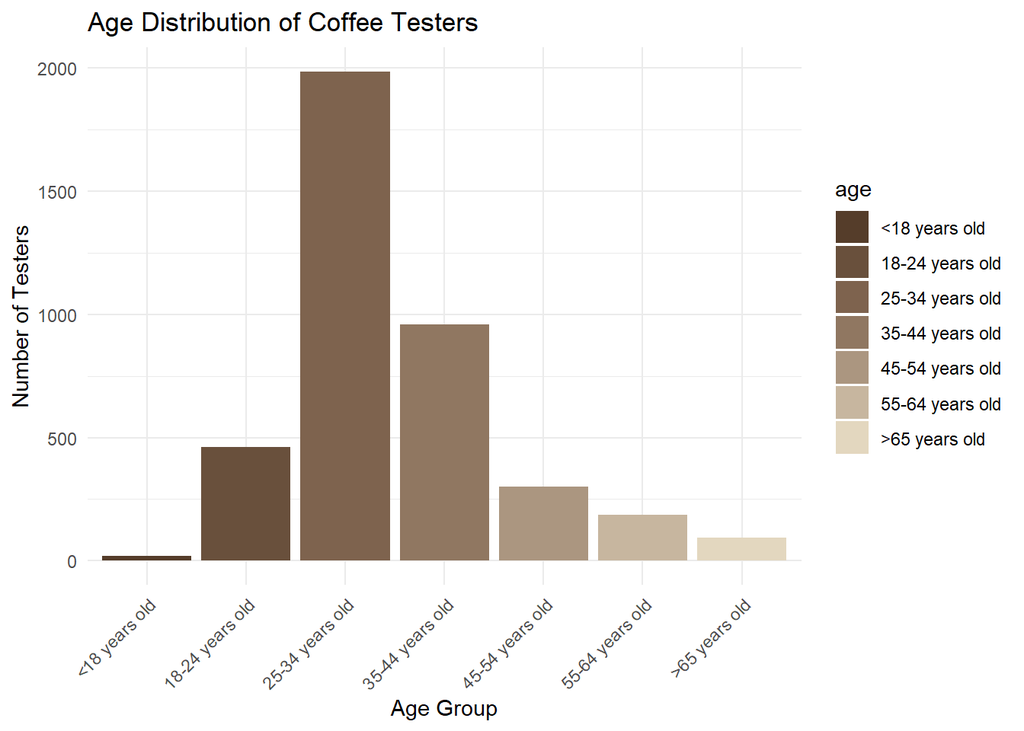

```r
# Plot to display the age distribution
Ageplot <- ggplot(coffee_data_filt_age, aes(x = age, y = count, fill = age)) +
  geom_bar(stat = "identity") +
  labs(title = "Age Distribution of Coffee Testers", x = "Age Group", y = "Number of Testers") +
  scale_fill_manual(values = brown_palette7) +
  theme_minimal() +
  theme(axis.text.x = element_text(angle = 45, hjust = 1))
print(Ageplot)
```

```r
# Grouping and reordering the data to display the brewing methods
coffee_data_cleaned_brew <- coffee_data %>%
  separate_rows(brew, sep = ", ") %>%
  mutate(brew = gsub(" \\(.*\\)$", "", brew)) %>%
  dplyr::filter(!is.na(brew)) %>%
  group_by(brew) %>%
  summarise(count = n()) %>%
  arrange(desc(count))
coffee_data_cleaned_brew$brew <- factor(coffee_data_cleaned_brew$brew, levels = coffee_data_cleaned_brew$brew)
print(head(coffee_data_cleaned_brew))
```

```
## # A tibble: 6 × 2
##   brew                   count
##   <fct>                  <int>
## 1 Pour over               2295
## 2 Espresso                1518
## 3 French press             735
## 4 Other                    677
## 5 Coffee brewing machine   663
## 6 Cold brew                525
```

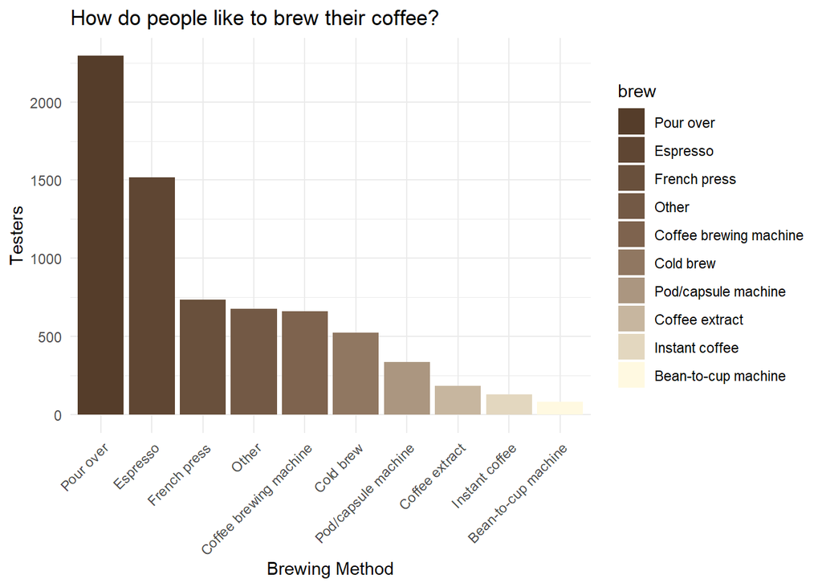

```r
# Plot to display the brewing methods
Brewplot <- ggplot(coffee_data_cleaned_brew , aes(x = reorder(brew, -count), y = count, fill = brew)) +
  geom_bar(stat = "identity") +
  labs(title = "How do people like to brew their coffee?", x = "Brewing Method", y = "Testers") +
  scale_fill_manual(values = brown_palette10) +
  theme_minimal() +
  theme(axis.text.x = element_text(angle = 45, hjust = 1))
print(Brewplot)
```

```r
# Grouping and reordering the data to display the coffee likes
coffee_data_favorite <- coffee_data %>%
  mutate(favorite = if_else(favorite == "Other", favorite_specify, favorite)) %>%
  dplyr::filter(!is.na(favorite)) %>%
  group_by(favorite) %>%
  summarise(count = n()) %>%
  mutate(count = as.numeric(count))

coffee_data_favorite <- coffee_data_favorite %>%
  mutate(favorite = if_else(count < 10, "Others", favorite)) %>%
  group_by(favorite) %>%
  summarise(count = sum(count)) %>%
  arrange(desc(count))

coffee_data_favorite$favorite <- factor(coffee_data_favorite$favorite, levels = coffee_data_favorite$favorite)
print(head(coffee_data_favorite))
```

```
## # A tibble: 6 × 2
##   favorite            count
##   <fct>               <dbl>
## 1 Pourover             1084
## 2 Latte                 680
## 3 Regular drip coffee   442
## 4 Cappuccino            341
## 5 Espresso              330
## 6 Cortado               313
```

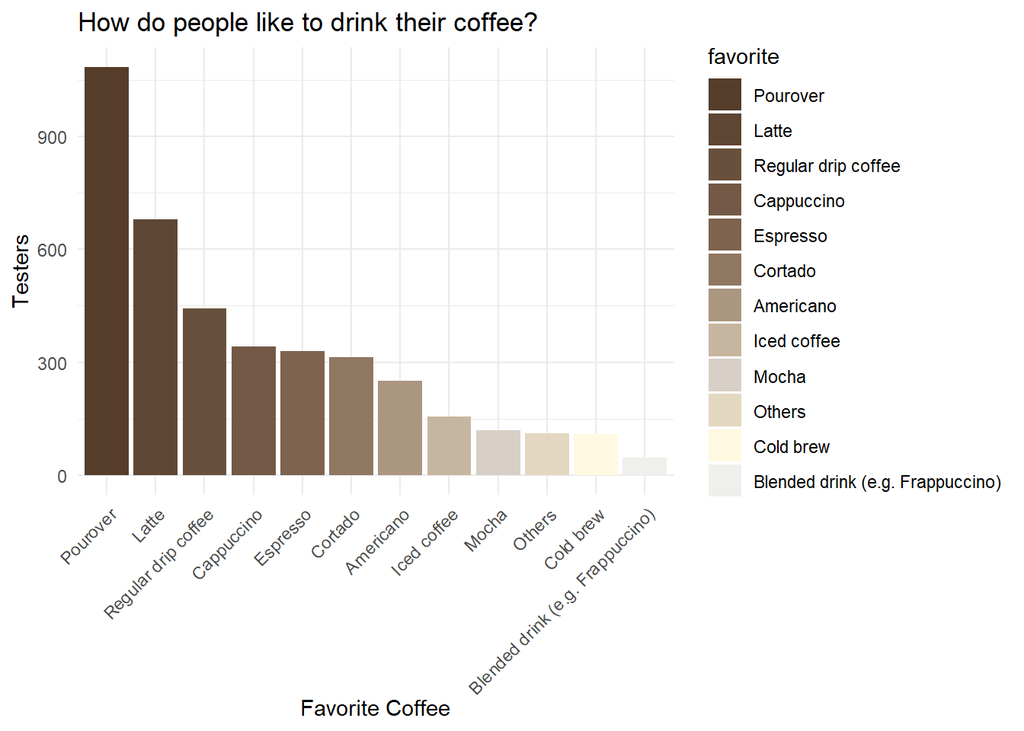

```r
# Plot to display the favorite coffees
Favoriteplot <- ggplot(coffee_data_favorite, aes(x = reorder(favorite, -count), y = count, fill = favorite)) +
  geom_bar(stat = "identity") +
  labs(title = "How do people like to drink their coffee?", x = "Favorite Coffee", y = "Testers") +
  scale_fill_manual(values = brown_palette12) +
  theme_minimal() +
  theme(axis.text.x = element_text(angle = 45, hjust = 1))
print(Favoriteplot)
```

```r
# Grouping and reordering the data to display where people like to drink coffee
coffee_data_place <- coffee_data %>%
  separate_rows(where_drink, sep = ", ") %>%
  dplyr::filter(!is.na(where_drink)) %>%
  group_by(where_drink) %>%
  summarise(count = n()) %>%
  arrange(desc(count))
coffee_data_place$where_drink <- factor(coffee_data_place$where_drink, levels = coffee_data_place$where_drink)
print(head(coffee_data_place))
```

```
## # A tibble: 5 × 2
##   where_drink   count
##   <fct>         <int>
## 1 At home        3644
## 2 At the office  1430
## 3 At a cafe      1170
## 4 On the go       705
## 5 None of these    36
```

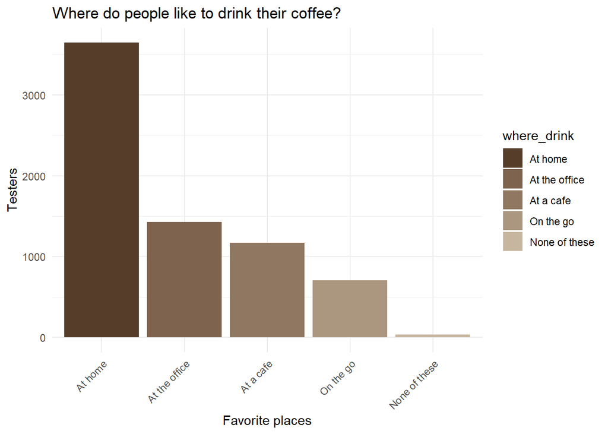

```r
# Plot to display where people like to drink coffee
Whereplot <- ggplot(coffee_data_place, aes(x = reorder(where_drink, -count), y = count, fill = where_drink)) +
  geom_bar(stat = "identity") +
  labs(title = "Where do people like to drink their coffee?", x = "Favorite places", y = "Testers") +
  scale_fill_manual(values = brown_palette5) +
  theme_minimal() +
  theme(axis.text.x = element_text(angle = 45, hjust = 1))
print(Whereplot)
```

## Now let’s explore if there are any gender differences in how much they are willing to spend on a coffee?

```r
# Cleaning and grouping the data to examine if there any difference in how much they are willing to spend on a coffee.
coffee_data_spending <- coffee_data %>%
  dplyr::filter(!is.na(gender) & !is.na(most_paid) & !is.na(most_willing) & !is.na(spent_equipment)) %>%
  mutate(most_paid = gsub("[^0-9.]", "", most_paid), most_paid = as.numeric(most_paid)) %>%
  mutate(most_willing = gsub("[^0-9.]", "", most_willing), most_willing = as.numeric(most_willing)) %>%
  mutate(spent_equipment = gsub("[^0-9.]", "", spent_equipment), spent_equipment = as.numeric(spent_equipment))

gender_spending <- coffee_data_spending %>%
  group_by(gender) %>%
  summarise(average_most_paid = mean(most_paid, na.rm = TRUE), average_most_willing = mean(most_willing, na.rm = TRUE), average_spent_equipment = mean(spent_equipment, na.rm = TRUE))

print(gender_spending)
```

```
## # A tibble: 5 × 4
##   gender           average_most_paid average_most_willing average_spent_equipm…¹
##   <chr>                        <dbl>                <dbl>                  <dbl>
## 1 Female                        484.                 555.                628249.
## 2 Male                          519.                 549.               1116968.
## 3 Non-binary                    627.                 693.                916812.
## 4 Other (please s…              582.                 575.               1161700
## 5 Prefer not to s…              556.                 516.                865200.
## # ℹ abbreviated name: ¹average_spent_equipment
```

```r
# Perform ANOVA's to compare means between genders
anova_most_paid <- aov(most_paid ~ gender, data = coffee_data_spending)
anova_most_willing <- aov(most_willing ~ gender, data = coffee_data_spending)
anova_spent_equipment <- aov(spent_equipment ~ gender, data = coffee_data_spending)
summary(anova_most_paid)
```

```
##               Df    Sum Sq Mean Sq F value Pr(>F)
## gender         4   2181967  545492   2.451 0.0441 *
## Residuals   3445 766682576  222549
## ---
## Signif. codes:  0 '***' 0.001 '**' 0.01 '*' 0.05 '.' 0.1 ' ' 1
```

```r
summary(anova_most_willing)
```

```
##               Df    Sum Sq Mean Sq F value Pr(>F)
## gender         4   2091644  522911   1.965 0.0972 .
## Residuals   3445 916937316  266165
## ---
## Signif. codes:  0 '***' 0.001 '**' 0.01 '*' 0.05 '.' 0.1 ' ' 1
```

```r
summary(anova_spent_equipment)
```

```
##               Df    Sum Sq   Mean Sq F value   Pr(>F)
## gender         4 1.492e+14 3.729e+13   10.45 2.07e-08 ***
## Residuals   3445 1.230e+16 3.570e+12
## ---
## Signif. codes:  0 '***' 0.001 '**' 0.01 '*' 0.05 '.' 0.1 ' ' 1
```

```r
# If ANOVA is significant, perform post-hoc tests
tukey_most_paid <- TukeyHSD(anova_most_paid)
tukey_spent_equipment <- TukeyHSD(anova_spent_equipment)
print(tukey_most_paid)
```

```
##   Tukey multiple comparisons of means
##     95% family-wise confidence level
##
## Fit: aov(formula = most_paid ~ gender, data = coffee_data_spending)
##
## $gender
##                                               diff         lwr       upr
## Male-Female                               34.76598  -16.994130  86.52608
## Non-binary-Female                        142.34625    7.203237 277.48927
## Other (please specify)-Female             97.69593 -333.812666 529.20452
## Prefer not to say-Female                  72.25865 -163.295311 307.81261
## Non-binary-Male                          107.58028  -22.493629 237.65419
## Other (please specify)-Male               62.92995 -367.018014 492.87792
## Prefer not to say-Male                    37.49268 -195.190060 270.17541
## Other (please specify)-Non-binary        -44.65033 -492.355341 403.05469
## Prefer not to say-Non-binary             -70.08760 -334.144002 193.96880
## Prefer not to say-Other (please specify) -25.43728 -512.942982 462.06843
##                                              p adj
## Male-Female                              0.3545126
## Non-binary-Female                        0.0331391
## Other (please specify)-Female            0.9722822
## Prefer not to say-Female                 0.9190457
## Non-binary-Male                          0.1592508
## Other (please specify)-Male              0.9946399
## Prefer not to say-Male                   0.9922490
## Other (please specify)-Non-binary        0.9987979
## Prefer not to say-Non-binary             0.9509147
## Prefer not to say-Other (please specify) 0.9999076
```

```r
print(tukey_spent_equipment)
```

```
##   Tukey multiple comparisons of means
##     95% family-wise confidence level
##
## Fit: aov(formula = spent_equipment ~ gender, data = coffee_data_spending)
##
## $gender
##                                                diff        lwr       upr
## Male-Female                               488718.96   281423.5  696014.4
## Non-binary-Female                         288562.57  -252675.3  829800.4
## Other (please specify)-Female             533450.80 -1194709.4 2261611.0
## Prefer not to say-Female                  236951.12  -706425.2 1180327.4
## Non-binary-Male                          -200156.39  -721092.8  320780.0
## Other (please specify)-Male                44731.84 -1677178.1 1766641.8
## Prefer not to say-Male                   -251767.83 -1183645.1  680109.4
## Other (please specify)-Non-binary         244888.24 -1548137.4 2037913.9
## Prefer not to say-Non-binary              -51611.44 -1109137.9 1005915.0
## Prefer not to say-Other (please specify) -296499.68 -2248924.2 1655924.8
##                                              p adj
## Male-Female                              0.0000000
## Non-binary-Female                        0.5918830
## Other (please specify)-Female            0.9173220
## Prefer not to say-Female                 0.9596551
## Non-binary-Male                          0.8325651
## Other (please specify)-Male              0.9999943
## Prefer not to say-Male                   0.9477545
## Other (please specify)-Non-binary        0.9958973
## Prefer not to say-Non-binary             0.9999292
## Prefer not to say-Other (please specify) 0.9938233
```

```r
# Descriptive statistics of genders and money spent on coffee
summary(gender_spending)
```

```
##     gender          average_most_paid average_most_willing
##  Length:5           Min.   :484.2     Min.   :516.1
##  Class :character   1st Qu.:519.0     1st Qu.:548.8
##  Mode  :character   Median :556.5     Median :555.4
##                     Mean   :553.6     Mean   :577.6
##                     3rd Qu.:581.9     3rd Qu.:574.8
##                     Max.   :626.5     Max.   :693.1
##  average_spent_equipment
##  Min.   : 628249
##  1st Qu.: 865200
##  Median : 916812
##  Mean   : 937786
##  3rd Qu.:1116968
##  Max.   :1161700
```

```r
descriptive_stats <- coffee_data_spending %>%
  group_by(gender) %>%
  summarise(
    count = n(),
    mean_most_paid = mean(most_paid, na.rm = TRUE),
    sd_most_paid = sd(most_paid, na.rm = TRUE),
    mean_most_willing = mean(most_willing, na.rm = TRUE),
    sd_most_willing = sd(most_willing, na.rm = TRUE),
    mean_spent_equipment = mean(spent_equipment, na.rm = TRUE),
    sd_spent_equipment = sd(spent_equipment, na.rm = TRUE)
  )
print(descriptive_stats)
```

```
## # A tibble: 5 × 8
##   gender     count mean_most_paid sd_most_paid mean_most_willing sd_most_willing
##   <chr>      <int>          <dbl>        <dbl>             <dbl>           <dbl>
## 1 Female       824           484.         444.              555.            492.
## 2 Male        2484           519.         480.              549.            523.
## 3 Non-binary   102           627.         479.              693.            546.
## 4 Other (pl…     9           582.         534.              575.            410.
## 5 Prefer no…    31           556.         453.              516.            514.
## # ℹ 2 more variables: mean_spent_equipment <dbl>, sd_spent_equipment <dbl>
```

```r
# Reporting ANOVA results
report(anova_most_paid)
```

```
## The ANOVA (formula: most_paid ~ gender) suggests that:
##
##   - The main effect of gender is statistically significant and very small (F(4,
## 3445) = 2.45, p = 0.044; Eta2 = 2.84e-03, 95% CI [3.78e-05, 1.00])
##
## Effect sizes were labelled following Field's (2013) recommendations.
```

```r
report(anova_spent_equipment)
```

```
## The ANOVA (formula: spent_equipment ~ gender) suggests that:
##
##   - The main effect of gender is statistically significant and small (F(4, 3445)
## = 10.45, p < .001; Eta2 = 0.01, 95% CI [5.94e-03, 1.00])
##
## Effect sizes were labelled following Field's (2013) recommendations.
```